# Coursera Machine Learning: Course Project

Akshay Bapte

20/07/2020

## Introduction

This project is part of the course **Practical Machine Learning**, of Data Specialization with R, from Johns Hopkins University.

Using devices such as Jawbone Up, Nike FuelBand, and Fitbit it is now possible to collect a large amount of data about personal activity relatively inexpensively. One thing that people regularly do is quantify how much of a particular activity they do, but they rarely quantify how well they do it. In this project, our goal will be to use data from accelerometers on the belt, forearm, arm, and dumbell of 6 participants.

The goal of this project is to predict the manner in which they did the exercise. We will use our prediction model to predict 20 different test cases.

## Data

The training data for this project are available here:

[Training data](https://d396qusza40orc.cloudfront.net/predmachlearn/pml-training.csv)

The test data are available here:

[Test data](https://d396qusza40orc.cloudfront.net/predmachlearn/pml-testing.csv)

## Loading the data

```r
library(caret)
library(rattle)
library(rpart)
library(rpart.plot)
library(RColorBrewer)
library(randomForest)
```

```r
train <- read.csv("pml-training.csv", header = TRUE)
test <- read.csv("pml-testing.csv", header = TRUE)
dim(train)
```

```
## [1] 19622   160
```

```r
dim(test)
```

```
## [1]  20 160
```

The training data contains 19622 observations from 160 variables and the test data contains 20 observations from 160 variables.

## Cleaning the data

Firstly, we will try to clean the data by removing **NA** values from both the data.

```r
train_clean <- train[, colSums(is.na(train)) == 0] # removing NAs
test_clean <- test[, colSums(is.na(test)) == 0]
dim(train_clean)
```

```
## [1] 19622    93
```

```r
dim(test_clean)
```

```
## [1] 20 60
```

```r
names(train_clean)
```

```
##  [1] "X"                       "user_name"
##  [3] "raw_timestamp_part_1"    "raw_timestamp_part_2"
##  [5] "cvtd_timestamp"          "new_window"
##  [7] "num_window"              "roll_belt"
##  [9] "pitch_belt"              "yaw_belt"
## [11] "total_accel_belt"        "kurtosis_roll_belt"
## [13] "kurtosis_picth_belt"     "kurtosis_yaw_belt"
## [15] "skewness_roll_belt"      "skewness_roll_belt.1"
## [17] "skewness_yaw_belt"       "max_yaw_belt"
## [19] "min_yaw_belt"            "amplitude_yaw_belt"
## [21] "gyros_belt_x"            "gyros_belt_y"
## [23] "gyros_belt_z"            "accel_belt_x"
## [25] "accel_belt_y"            "accel_belt_z"
## [27] "magnet_belt_x"           "magnet_belt_y"
## [29] "magnet_belt_z"           "roll_arm"
```

[output cut: 32 more lines]

Having a quick look at the train_clean data shows us that the first 7 variables: **“X”**, **“user_name”**, **“raw_timestamp_part_1”**, **“raw_timestamp_part_2”**, **“cvtd_timestamp”**, **“new_window”**, and **“num_window”** cannot be used as the predictors in our prediction models, so we will remove this variables from our data.

```r
train_clean <- train_clean[, -c(1:7)]
test_clean <- test_clean[, -c(1:7)]
dim(test_clean)
```

```
## [1] 20 53
```

```r
dim(train_clean)
```

```
## [1] 19622    86
```

## Partitioning the data

We will now partition our cleaned train data ( **train_clean** ) into 70% **train_data** and 30% **test_data**. This partitioning will allow us to test our predictions before testing it on the raw test data provided to us.

```r
set.seed(1254)
inTrain <- createDataPartition(train_clean$classe, p = 0.7, list = FALSE)
train_data <- train_clean[inTrain, ]
test_data <- train_clean[-inTrain, ]
dim(train_data)
```

```
## [1] 13737    86
```

```r
dim(test_data)
```

```
## [1] 5885   86
```

## Removing variables with Near Zero variance

We will further clean the data by removing the variables that have Near Zero Variance.

```r
NZV <- nearZeroVar(train_data)
train_data <- train_data[, -NZV]
test_data <- test_data[, -NZV]
dim(train_data)
```

```
## [1] 13737    53
```

```r
dim(test_data)
```

```
## [1] 5885   53
```

## Building a model

### 1. Classification tree using rpart

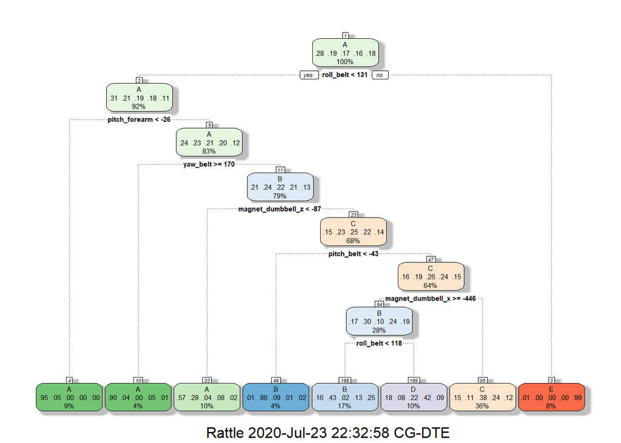

```r
fit1 <- train(classe~., train_data, method = "rpart")
fancyRpartPlot(fit1$finalModel)
```

### 2. Random forest

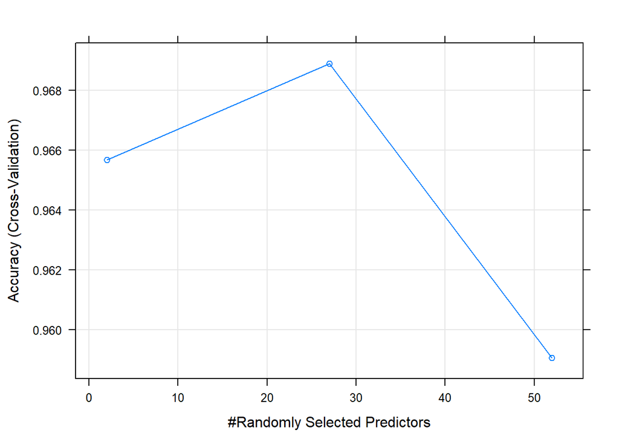

```r
controlRF <- trainControl(method="cv", number=3, verboseIter=FALSE)
fit2 <- train(classe~., test_data, method = "rf", trControl = controlRF)
plot(fit2)
```

We will use the both the **fit1** and **fit2** models on our **test_data** using predict and confusionMatrix used to calculate the accuracy of the prediction.

```r
predict1 <- predict(fit1, test_data)
confusion1 <- confusionMatrix(predict1, as.factor(test_data$classe))
confusion1
```

```
## Confusion Matrix and Statistics
##
##           Reference
## Prediction    A    B    C    D    E
##          A 1081  223   37   57   21
##          B  166  630   50  142  253
##          C  326  237  807  510  249
##          D  100   49  132  255   65
##          E    1    0    0    0  494
##
## Overall Statistics
##
##                Accuracy : 0.5551
##                  95% CI : (0.5423, 0.5679)
##     No Information Rate : 0.2845
##     P-Value [Acc > NIR] : < 2.2e-16
##
##                   Kappa : 0.4407
##
##  Mcnemar's Test P-Value : < 2.2e-16
##
## Statistics by Class:
##
##                      Class: A Class: B Class: C Class: D Class: E
## Sensitivity            0.6458   0.5531   0.7865  0.26452  0.45656
## Specificity            0.9197   0.8713   0.7279  0.92969  0.99979
## Pos Pred Value         0.7618   0.5077   0.3791  0.42429  0.99798
## Neg Pred Value         0.8672   0.8904   0.9417  0.86582  0.89091
## Prevalence             0.2845   0.1935   0.1743  0.16381  0.18386
## Detection Rate         0.1837   0.1071   0.1371  0.04333  0.08394
## Detection Prevalence   0.2411   0.2109   0.3618  0.10212  0.08411
## Balanced Accuracy      0.7827   0.7122   0.7572  0.59711  0.72818
```

The accuracy of the model fit1 is **0.5551** and out of sample error is **0.45***.

```r
predict2 <- predict(fit2, newdata = test_data)
cm2 <- confusionMatrix(predict2, as.factor(test_data$classe))
cm2
```

```
## Confusion Matrix and Statistics
##
##           Reference
## Prediction    A    B    C    D    E
##          A 1674    0    0    0    0
##          B    0 1139    0    0    0
##          C    0    0 1026    0    0
##          D    0    0    0  964    0
##          E    0    0    0    0 1082
##
## Overall Statistics
##
##                Accuracy : 1
##                  95% CI : (0.9994, 1)
##     No Information Rate : 0.2845
##     P-Value [Acc > NIR] : < 2.2e-16
##
##                   Kappa : 1
##
##  Mcnemar's Test P-Value : NA
##
## Statistics by Class:
##
##                      Class: A Class: B Class: C Class: D Class: E
## Sensitivity            1.0000   1.0000   1.0000   1.0000   1.0000
## Specificity            1.0000   1.0000   1.0000   1.0000   1.0000
## Pos Pred Value         1.0000   1.0000   1.0000   1.0000   1.0000
## Neg Pred Value         1.0000   1.0000   1.0000   1.0000   1.0000
## Prevalence             0.2845   0.1935   0.1743   0.1638   0.1839
## Detection Rate         0.2845   0.1935   0.1743   0.1638   0.1839
## Detection Prevalence   0.2845   0.1935   0.1743   0.1638   0.1839
## Balanced Accuracy      1.0000   1.0000   1.0000   1.0000   1.0000
```

## Applying the best model

```r
predictor <- predict(fit2, newdata = test)
final_submission <- data.frame(test$problem_id, predictor)
final_submission
```

```
##    test.problem_id predictor
## 1                1         B
## 2                2         A
## 3                3         B
## 4                4         A
## 5                5         A
## 6                6         E
## 7                7         D
## 8                8         B
## 9                9         A
## 10              10         A
## 11              11         B
## 12              12         C
## 13              13         B
## 14              14         A
## 15              15         E
## 16              16         E
## 17              17         A
## 18              18         B
## 19              19         B
## 20              20         B
```

We will use this predictors to answer the questions from the Course quiz.